# Proyecto Final: Análisis de la Lotería de Santander

Tomas Castro - Jhon Salazar

2024-12-03

# Loteria de Santander Analisis

## Introducción

El objetivo principal de este proyecto es realizar un análisis exhaustivo de los datos relacionados con los ganadores de la Lotería de Santander, utilizando el conjunto de datos denominado lottery_csvset. Este análisis tiene como propósito aplicar los conocimientos adquiridos en la materia de Estadistica 1, a fin de proporcionar una visión profunda sobre los patrones y tendencias presentes en los resultados de la lotería.

Este proyecto tiene como propósito no solo generar un análisis descriptivo de los datos, sino también proporcionar información útil que podría servir para futuros estudios o para la toma de decisiones relacionadas con los sorteos de la Lotería de Santander.

## Paquetes requeridos

```r
# Instalar paquetes necesarios (si no están instalados)
if (!require(tidyverse)) install.packages("tidyverse")
```

```r
if (!require(ggplot2)) install.packages("ggplot2")
if (!require(dplyr)) install.packages("dplyr")
if (!require(kableExtra)) install.packages("kableExtra")
# Cargar librerías
library(tidyverse)
library(ggplot2)
library(dplyr)
library(kableExtra)
```

## Metodologia

### Obtencion de los Datos

Los datos utilizados en este análisis provienen de un archivo CSV titulado “resultados_por_sorteo_loteria_santander_20241127.csv”, el cual contiene información histórica sobre los sorteos y ganadores de la Lotería de Santander. Este conjunto de datos incluye variables como el número ganador, el tipo de premio, el sorteo, y la serie correspondiente a cada ganador. Los datos fueron obtenidos directamente de la pagina de datos oficial del gobierno de colombia, lo que garantiza que la información esté actualizada hasta la fecha más reciente disponible (noviembre 2024).

### Limpieza de los datos

Los datos fueron cargados en R utilizando la función read_csv() del paquete readr. El archivo CSV es el formato estándar para la recopilación de datos de la lotería, permitiendo su fácil importación a un entorno de análisis.

```r
lottery_csv <- read_csv("./resultados_por_sorteo_loteria_santander_20241127.csv")
lottery_csv <- lottery_csv %>%
  mutate(
    PREMIO = str_to_upper(PREMIO),
    PREMIO = case_when(
      PREMIO %in% c("PREMIO SECO DE 3 MILLONES", "SECOS DE 3 MILLONES") ~ "SECO DE 3 MILLONES",
      PREMIO %in% c("SECO DE 5 M", "SECO DE 5 MILLONES") ~ "SECO DE 5 MILLONES",
      PREMIO %in% c("SECO DE 10 M", "SECO DE 10 MILLONES", "PREMIO SECO DE 10 MILLONES") ~ "SECO DE 10 MILLONES",
      PREMIO %in% c("SECO DE 20 M", "PREMIO SECO DE 20 MILLONES", "SECO DE 20 MILLONES") ~ "SECO DE 20 MILLONES",
      PREMIO %in% c("SECO DE 50 M", "SECO DE 50 MILLONES") ~ "SECO DE 50 MILLONES",
      PREMIO %in% c("SECO DE 100 M", "SECO DE 100 MILLONES", "PREMIO SECO DE 100 MILLONES") ~ "SECO DE 100 MILLONES",

      TRUE ~ PREMIO
    ),
    NUMERO = as.numeric(NUMERO)
  )

categorias_agrupadas <- lottery_csv %>%
  count(PREMIO) %>%
  arrange(desc(n))
```

## Resultados

#### Distribución de premios

Una vez organizada y limpiada la informacion, se procede a graficar como se distribuyen los premios, para asi tener una idea mas clara de cuales son los que tienen mas registros y cuales por el contrario tienen pocas apariciones

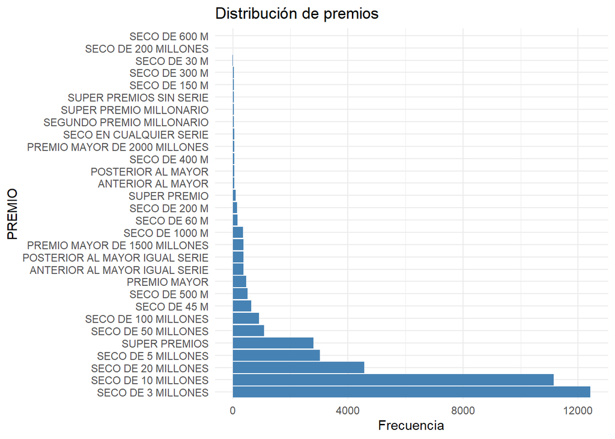

```r
premios_frecuencia <- lottery_csv %>% group_by(PREMIO) %>% summarise(count = n())

ggplot(premios_frecuencia, aes(x = reorder(PREMIO, -count), y = count)) +
  geom_bar(stat = "identity", fill = "steelblue") +
  coord_flip() +
  labs(title = "Distribución de premios", x = "PREMIO", y = "Frecuencia") +
  theme_minimal()
```

Luego acotamos a 10 los premios, ya que se evidencia que en ellos es donde se tiene la mayor distribucion de registros

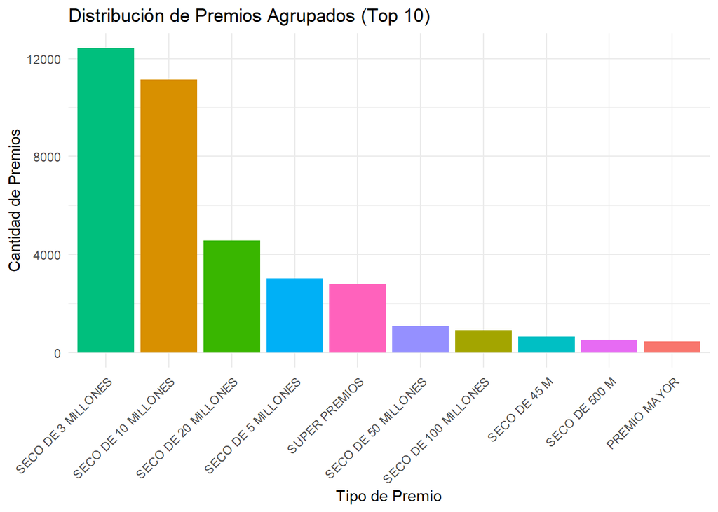

```r
lottery_csv %>%
  count(PREMIO) %>%
  arrange(desc(n)) %>%
  slice(1:10) %>%
  ggplot(aes(x = reorder(PREMIO, -n), y = n, fill = PREMIO)) +
  geom_bar(stat = "identity") +
  labs(
    title = "Distribución de Premios Agrupados (Top 10)",
    x = "Tipo de Premio",
    y = "Cantidad de Premios"
  ) +
  theme_minimal() +
  theme(
    axis.text.x = element_text(angle = 45, hjust = 1),
    legend.position = "none"
  )
```

Por ultimo, calculamos la probabilidad de ganar uno de los 10 primeros premios en base a la informacion suministrada, obteniendo la siguiente tabla

```r
premios_frecuencia <- lottery_csv %>%
  count(PREMIO) %>%
  arrange(desc(n))

top_10_premios <- premios_frecuencia %>%
  slice(1:10)

total_premios <- sum(premios_frecuencia$n)

premios_frecuencia <- premios_frecuencia  %>%
  mutate(probabilidad = (n / total_premios) * 100) %>%
  mutate(probabilidad = paste0(round(probabilidad, 2), "%"))

top_10_premios <- premios_frecuencia %>%
  slice(1:10)

top_10_premios %>%
  select(PREMIO, n, probabilidad) %>%
  kable("html", col.names = c("Premio", "Número de Premios", "Probabilidad (%)")) %>%
  kable_styling("striped", full_width = F) %>%
  column_spec(1, bold = TRUE, color = "white", background = "#0073e6") %>%
  column_spec(2, background = "#f2f2f2") %>%
  column_spec(3, background = "#d9edf7") %>%
  row_spec(0, bold = TRUE, color = "white", background = "#333333")
```

| Premio | Número de Premios | Probabilidad (%) |
| --- | --- | --- |
| SECO DE 3 MILLONES | 12420 | 31.16% |
| SECO DE 10 MILLONES | 11149 | 27.97% |
| SECO DE 20 MILLONES | 4564 | 11.45% |
| SECO DE 5 MILLONES | 3020 | 7.58% |
| SUPER PREMIOS | 2800 | 7.02% |
| SECO DE 50 MILLONES | 1091 | 2.74% |
| SECO DE 100 MILLONES | 905 | 2.27% |
| SECO DE 45 M | 640 | 1.61% |
| SECO DE 500 M | 519 | 1.3% |
| PREMIO MAYOR | 461 | 1.16% |

#### Análisis de SERIEs

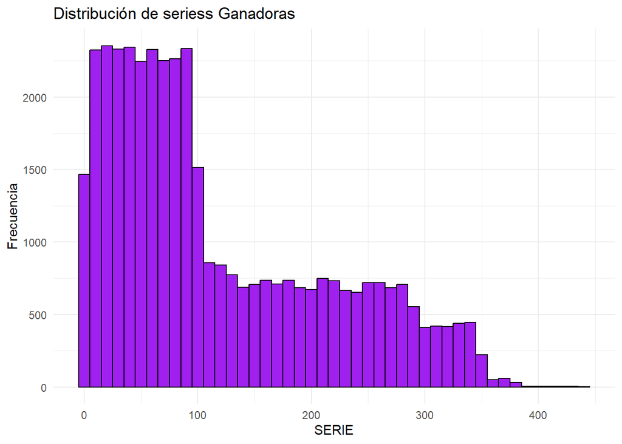

```r
ggplot(lottery_csv, aes(x = SERIE)) +
  geom_histogram(binwidth = 10, fill = "purple", color = "black") +
  labs(title = "Distribución de seriess Ganadoras", x = "SERIE", y = "Frecuencia") +
  theme_minimal()
```

## Conclusiones

Este análisis permite identificar patrones y tendencias en los resultados de la lotería, ayudando a entender mejor las dinámicas de los SORTEOs.

## Referencias

https://www.datos.gov.co/Comercio-Industria-y-Turismo/resultados-por-sorteo-loteria-santander/4zwu-ra3f/about_data